# SmithProject_Women In Movies_Jun2022

## Women In Movies: Bechdel Test Results Over Time

### Jennifer Smith

#### June 7, 2022

For this project, I explored a dataset of movies and whether they pass or fail the "Bechdel Test", the well-known test that examines the portrayal of women in movies. To pass, a movie must pass three tests: it has at least two named female characters, they talk to eachother, and they talk about something other than men. The data was downloaded from: https://www.kaggle.com/datasets/mathurinache/women-in-movies?resource=download

```python
import pandas as pd
movies = pd.read_csv('movies.csv')
movies.head()
```

|  | year | imdb | title | test | clean_test | binary | budget | domgross | intgross | code | budget_2013$ | domgross_2013$ | intgross_2013$ | period code | decade code |
| --- | --- | --- | --- | --- | --- | --- | --- | --- | --- | --- | --- | --- | --- | --- | --- |
| 0 | 1970 | tt0065466 | Beyond the Valley of the Dolls | ok | ok | PASS | 1000000 | 9000000.0 | 9000000.0 | 1970PASS | 5997631 | 53978683.0 | 53978683.0 | NaN | NaN |
| 1 | 1971 | tt0067065 | Escape from the Planet of the Apes | notalk | notalk | FAIL | 2500000 | 12300000.0 | 12300000.0 | 1971FAIL | 14386286 | 70780525.0 | 70780525.0 | NaN | NaN |
| 2 | 1971 | tt0067741 | Shaft | notalk | notalk | FAIL | 53012938 | 70327868.0 | 107190108.0 | 1971FAIL | 305063707 | 404702718.0 | 616827003.0 | NaN | NaN |
| 3 | 1971 | tt0067800 | Straw Dogs | notalk | notalk | FAIL | 25000000 | 10324441.0 | 11253821.0 | 1971FAIL | 143862856 | 59412143.0 | 64760273.0 | NaN | NaN |
| 4 | 1971 | tt0067116 | The French Connection | notalk | notalk | FAIL | 2200000 | 41158757.0 | 41158757.0 | 1971FAIL | 12659931 | 236848653.0 | 236848653.0 | NaN | NaN |

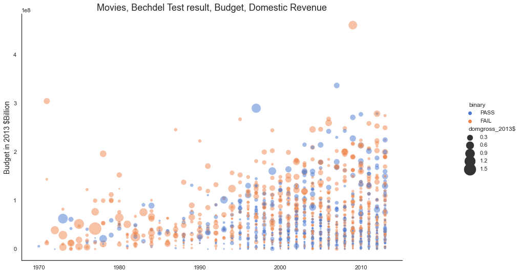

```python
import pandas as pd
import seaborn as sns
import matplotlib.pyplot as plt

sns.set_theme(style="white")

sns.relplot(x="year", y="budget_2013$", hue="binary", size="domgross_2013$",
            sizes=(10, 600), alpha=.5, palette="muted",
            height=6, data=movies, legend='brief')

plt.gcf().set_size_inches(15, 8)

plt.xlabel('')
plt.ylabel('Budget in 2013 $Billion', fontsize=14)
plt.title('Movies, Bechdel Test result, Budget, Domestic Revenue', fontsize=18)
```

6/3 Update: I was able to adjust the size of the plot since my first post! It's definitely much easier to view now, but I still think my bar and line charts tell the story more clearly.

This was the first visualization I tried. It captures the raw number of movies that pass or fail the test over time, as well as the budget of those movies and the domestic revenue they brought in. I do think this is an interesting visual, and when studying it you can draw some conclusions, but for many purposes I think it is likely too much information.

```python
count_per_year = movies.pivot_table('test', index = 'year', columns = 'binary', aggfunc = 'count')
count_per_year['Total'] = count_per_year['FAIL'] + count_per_year['PASS']
count_per_year.head()
```

| binary year | FAIL | PASS | Total |
| --- | --- | --- | --- |
| 1970 | NaN | 1.0 | NaN |
| 1971 | 5.0 | NaN | NaN |
| 1972 | 2.0 | 1.0 | 3.0 |
| 1973 | 4.0 | 1.0 | 5.0 |
| 1974 | 5.0 | 2.0 | 7.0 |

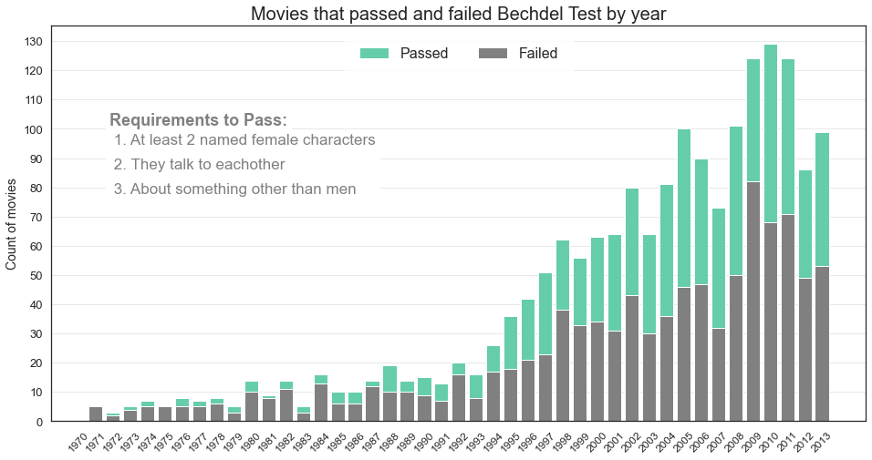

```python
import numpy as np
import matplotlib.pyplot as plt

N = len(count_per_year)
ind = np.arange(N)

plt.figure(figsize=(16,8))
plt.grid(visible=False, which='both', axis='x')
plt.grid(visible=True, which='both', axis='y', color='lightgrey', linestyle='-', linewidth=0.5)

p1 = plt.bar(ind, count_per_year['Total'], color = 'mediumaquamarine')
p2 = plt.bar(ind, count_per_year['FAIL'], color = 'grey')

plt.ylabel('Count of movies', fontsize=14)
plt.title('Movies that passed and failed Bechdel Test by year', fontsize=20)
plt.xticks(ind, count_per_year.index.values, rotation=45, fontsize=12)
plt.yticks(np.arange(0, 140, 10), fontsize=13)
plt.legend((p1[0], p2[0]), ('Passed', 'Failed'), fontsize=16, frameon=True,
           facecolor='white', edgecolor="white", borderpad=1, ncol=2)

plt.figtext(0.18, 0.69, 'Requirements to Pass:', fontsize=18, fontweight='bold', color='grey', backgroundcolor='white')
plt.figtext(0.18, 0.58, ' 1. At least 2 named female characters\n 2. They talk to eachother\n 3. About something other than men',
            fontsize=17, color='grey', linespacing=2, wrap=True, backgroundcolor='white')

plt.show()
```

After the first visualization that tried to do too much, I wanted something straigthforward that would quickly convey how many movies still don't pass the test (by count). I think this stacked bar chart shows the difference quite clearly. To get this to work I first created a pivot table from the original dataset, then used the new df for the visualization. I also played around a lot with formatting - colors, gridlines, fonts - and included text to explain the test for viewers who might not be familiar.

```python
budget = movies.pivot_table('budget_2013$', index = 'year', columns = 'binary', aggfunc='sum')
budget.head()
```

| binary year | FAIL | PASS |
| --- | --- | --- |
| 1970 | NaN | 5997631.0 |
| 1971 | 493236323.0 | NaN |
| 1972 | 61293532.0 | 66866.0 |
| 1973 | 125732851.0 | 62926730.0 |
| 1974 | 34388727.0 | 103921974.0 |

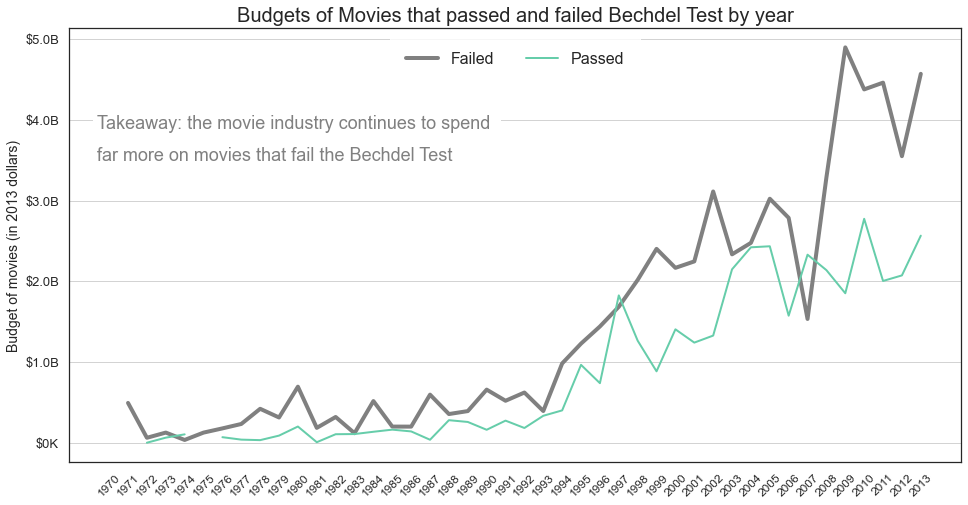

```python
import numpy as np
import matplotlib.pyplot as plt

fig, ax = plt.subplots(figsize=(16, 8))

plt.grid(visible=False, which='both', axis='x')
plt.grid(visible=True, which='major', axis='y', color='lightgrey', linestyle='-', linewidth=1)
plt.grid(visible=True, which='minor', axis='y', color='lightgrey', linestyle='-', linewidth=0.5)

line1, = ax.plot(budget.index.values, budget['FAIL'], label='Failed', color = 'grey', linewidth=4)
line2, = ax.plot(budget.index.values, budget['PASS'], label='Passed', color= 'mediumaquamarine', linewidth=2)

def currency(x, pos):

    if x >= 1e6:
        s = '${:1.1f}B'.format(x*1e-9)
    else:
        s = '${:1.0f}K'.format(x*1e-3)
    return s

ax.yaxis.set_major_formatter(currency)
plt.title('Budgets of Movies that passed and failed Bechdel Test by year', fontsize=20)
plt.ylabel('Budget of movies (in 2013 dollars)', fontsize=14)
plt.xticks(budget.index.values, rotation=45, fontsize=12)
plt.yticks(fontsize=13)

plt.figtext(0.15, 0.65, 'Takeaway: the movie industry continues to spend \nfar more on movies that fail the Bechdel Test',
            fontsize=18, color='grey', backgroundcolor='white', linespacing=2)

ax.legend(fontsize=16, frameon=True, loc='upper center',
           facecolor='white', edgecolor='white', borderpad=1, ncol=2)
plt.show()
```

To go along with the preceding bar chart, I decided to try a line chart that shows the budgets of movies that pass and fail over time. I wanted to look at the budgets to make the point that the movie industry is proliferating the problem by continuing to under fund movies with solid female representation. Yes, budgeting for movies that pass has grown over time, but budgeting for movies that fail has grown faster in the same amount of time.